# Trends in Minnesota Lake Ice

Christopher Rounds

5/4/2022

# Ice Duration

Lake ice data can be complex and highly variable. Many things impact when lakes freeze and when they thaw. In this modeling effort I have a couple different predictors of lake ice that are thought to be important. The predictor we are mainly focusing on is the year of the record. As climate change has heated the surface of the planet we expect lake ice to occur for a shorter time period, lakes to freeze later and ice to thaw earlier.  
The model type I am going to use is called a Generalized Additive Mixed Model (GAMM). GAMMs can model nonlinear relationships and can do a good job accounting for the variation between individual lakes (by fitting a random effect for each lake). If you want a more formal introduction to GAMs, [Environmental Computing](https://environmentalcomputing.net/statistics/gams/) has a good tutorial on GAMs.

# Formula for Ice duration

```
## duration ~ US_L3NAME + s(log_acres, k = 4) + s(max_depth, k = 4) +
##     s(DOW, bs = "re") + s(winter_year, k = 4) + s(lat, long) +
##     s(ENSOw) + s(QBOw) + s(SUNw)
```

The variable US_L3NAME is the ecoregion that the lake is in. Log_acres is the log transformed surface area o the lake in acres. Max_depth is the maximum depth of the lake in meters. DOW is the unique ID for the lake and bs = “re” means we want a random intercept for each lake. Winter_year is the year that the ice melted (so for the winter of 2021-2022 winter_year would be 2022). lat and long represent the center of the lake and this will create a spatial smooth. Finally the last three variables are climatic variables that are taken as averages from October - May.

# How is Lake Ice Duration Changing Since 1950?

[figure not shown]

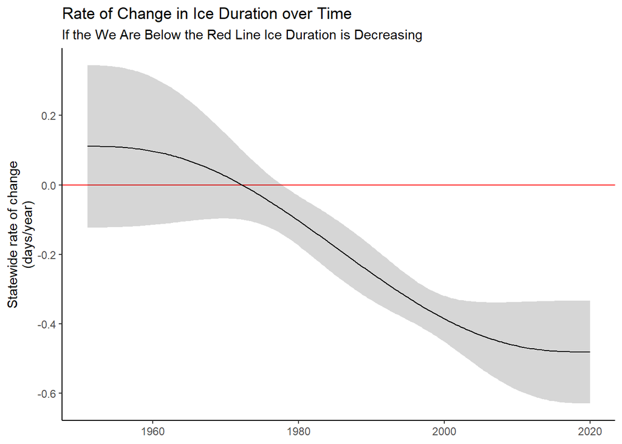

If we want to see how a variable impacts the duration of lake ice we can do that! Here is how the maximum depth of a lake is predicted to change the ice duration.

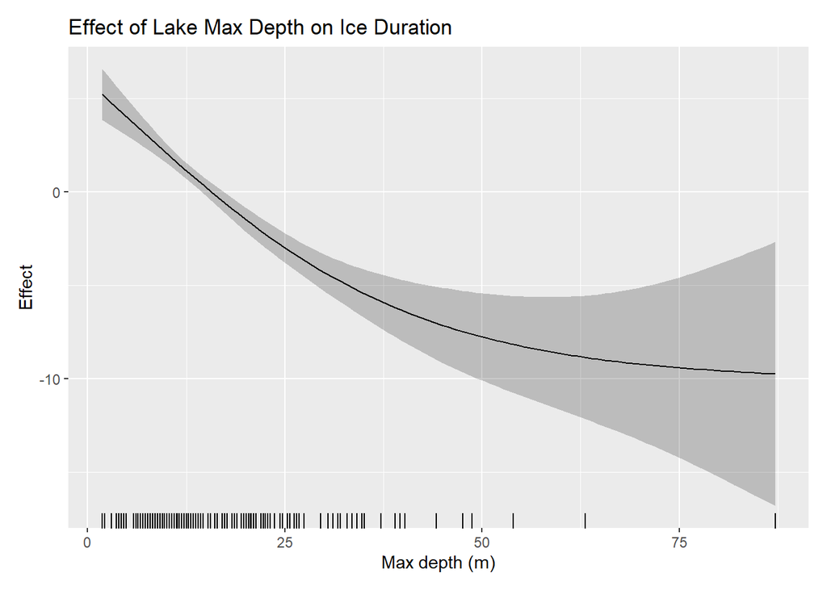

We can see as max depth increases, the effect becomes negative. This means that lakes that are deeper are likely to have a shorter ice duration.

# Formula for Ice-On

```
## jd_in ~ US_L3NAME + log_acres + s(max_depth, k = 4) + s(DOW,
##     bs = "re") + s(winter_year, k = 4) + s(shore_mi, k = 4) +
##     s(lat, long) + s(ENSOfw) + s(QBOfw) + s(SUNfw)
```

# Effect of Max-Depth on Lake Ice-On

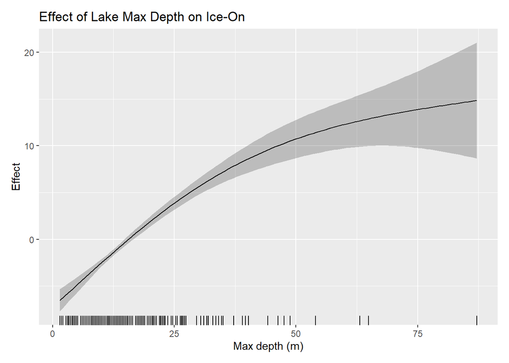

This should make sense. As lakes are bigger they likely have a larger area, are absorbing more sunlight through the summer which takes a longer time to cool off in the winter. This is partially why really big lakes, like Lake Superior, never completely freeze.

# How is Lake Ice-On Changing Since 1950?

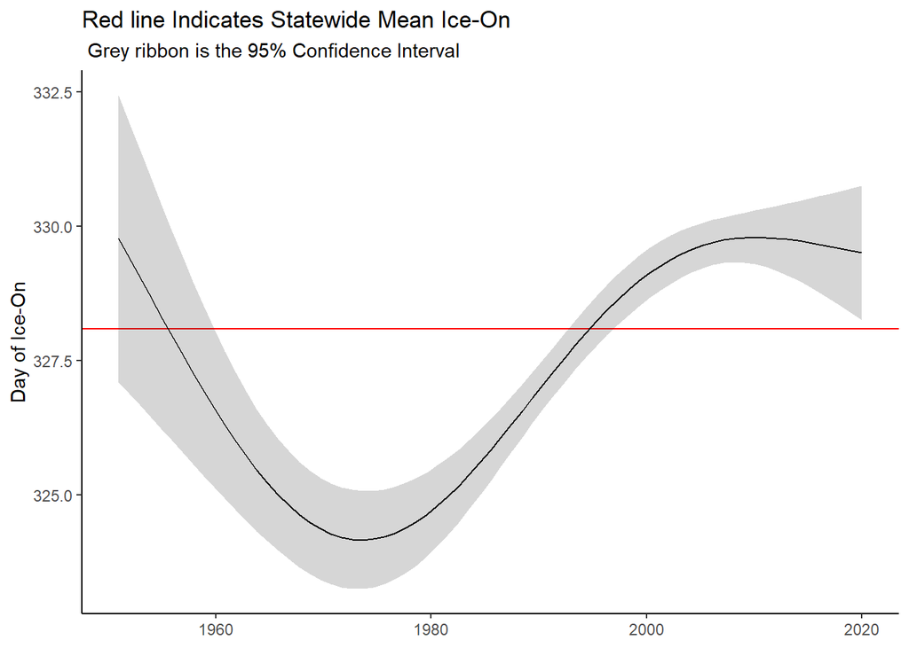

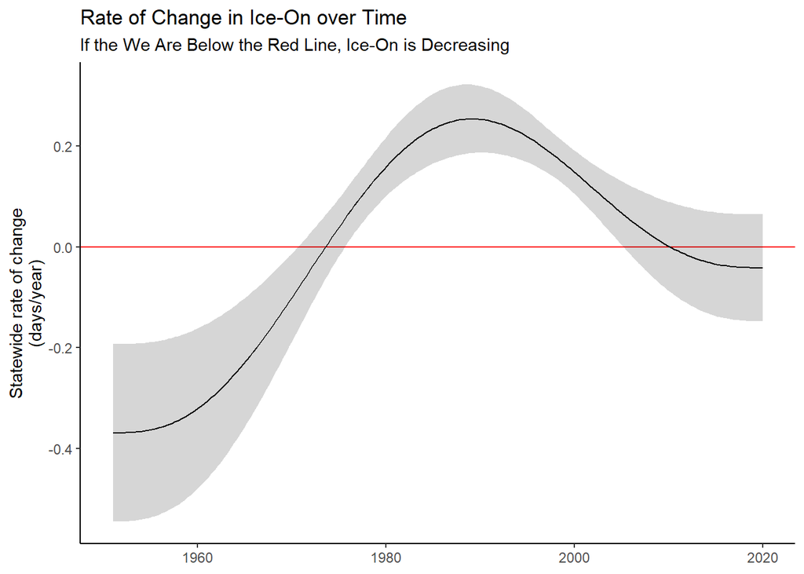

# Formula for Ice-Off

[output not shown]

# Effect of Max-Depth on Lake Ice-Off

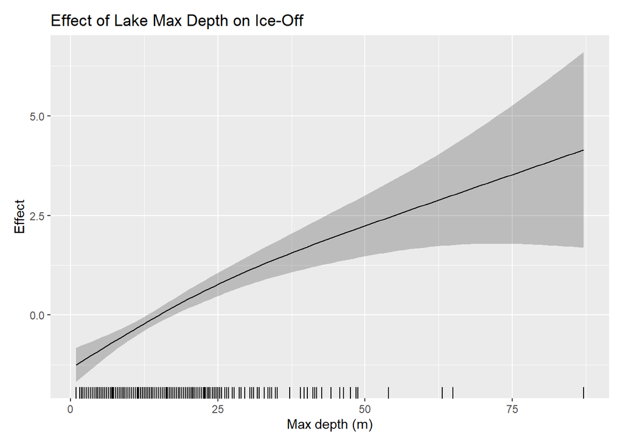

This plot is showing that as max depth increases, the ice-off date for a lake should also get later. That is to say, lakes that are deeper keep their ice on for longer.

# How is Lake Ice-Off Changing Since 1950?

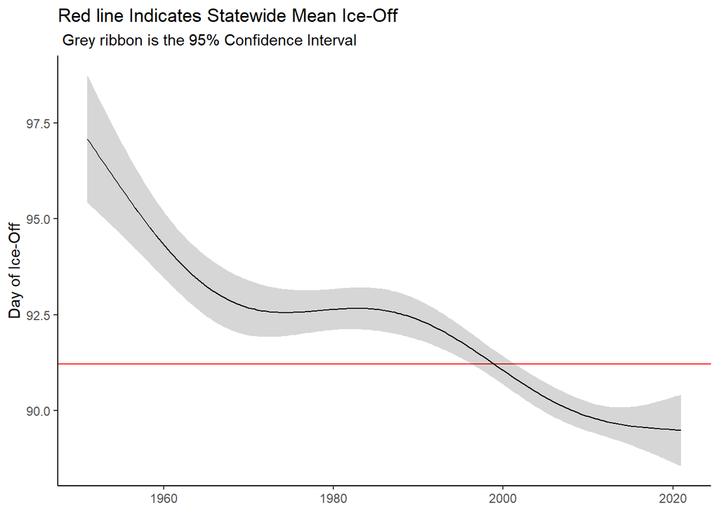

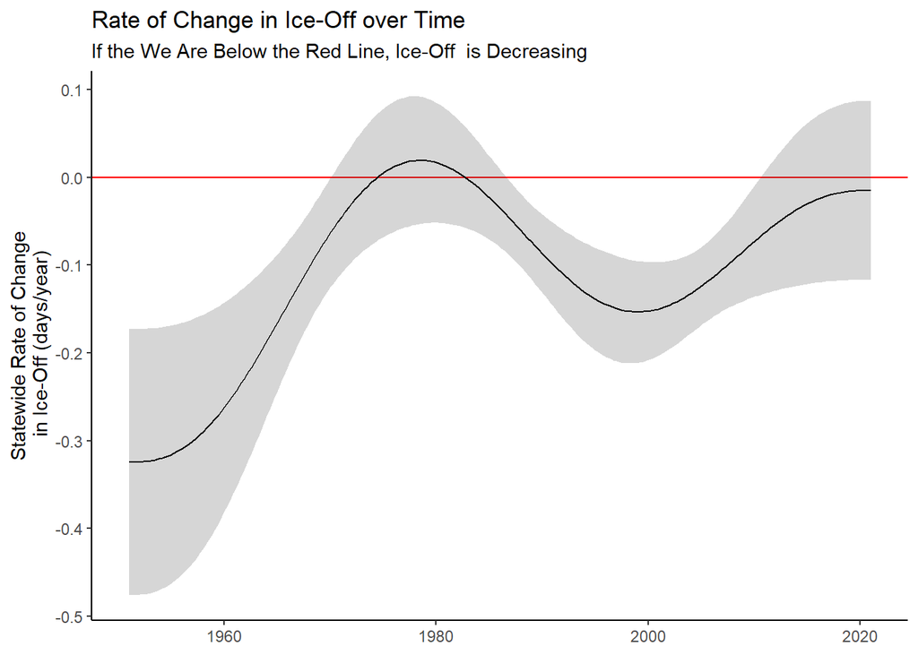

These first ice-off plot is pretty easy to tell whats happening. The ice-off data is clearly getting earlier as the year increases. in this plot you can tell why a GAMM may be a suitable modeling technique due to the non linearity of the trend.